# Objective: To increase conversions for customers.

# Observation 2

Dress catagoury has more count.

```python
df1
```

|  | PID | Product Name | Category | Color | Primary Color | Fabric |
| --- | --- | --- | --- | --- | --- | --- |
| 0 | CL0036386 | Ikat stripe print cotton knit dress | Dress | Blue/navy/white | Blue | Cotton Spandex |
| 1 | CL0030567 | Feminine pleated knit dress | Dress | Navy blue | Navy blue | Cotton Spandex |
| 2 | CL0032320 | Floral embellished chambray denim maxi dress | Dress | Deep indigo | Deep indigo | Cotton |
| 3 | CL0036700 | Dot print cap sleeve shirt | Top | White/navy | White | Cotton |
| 4 | CL0036365 | Layered asymmetric hem hacci knit top | Top | Blue | Blue | Polyester |
| ... | ... | ... | ... | ... | ... | ... |
| 711 | CL0031288 | Ruffle front poplin dress | Dress | Spring green | Spring green | Cotton |
| 712 | CL0032199 | Beaded cotton poplin sheath dress | Dress | Spring green | Spring green | Cotton |
| 713 | CL0031267 | Embellished stripe waist poplin dress | Dress | Spring green multi | Spring green multi | Cotton |
| 714 | CL0031287 | Sash waist poplin skirt | Skirt | Spring green | Spring green | Cotton |
| 715 | CL0031947 | Colorblock retro poplin frock | Dress | Black/spring green | Black | Cotton |

716 rows × 6 columns

```python
##count of category
df1["Category"].value_counts()
```

```
 Dress       428
 Top         147
 Skirt        72
 Pant         49
 Jumpsuit     11
 Jacket        9
Name: Category, dtype: int64
```

# observation 3

Catagory dress has more count hence user has more search Dress. jacket has not more demand may be this data is created from summer .

```python
##count of fabric
df1["Fabric"].value_counts()
```

```
 Cotton                      263
 Cotton Spandex              139
 Polyester                   104
 Polyester Crepe de Chine     43
 Polyester Spandex            32
 Viscose Spandex              20
 Cotton Polyester             17
 Cotton Polyester Spandex     17
 Polyamide Spandex            12
 Rayon Nylon Spandex          12
 Rayon Polyester Spandex       7
 Silk                          7
 Cotton Nylon                  6
 Rayon                         6
 Polyester Rayon Spandex       4
 Polyester Nylon               4
 Viscose                       4
 Cotton Rayon Spandex          4
 Tencel                        3
 Nylon                         3
 Nylon Polyester               2
 Polyester Rayon               2
 Polyester Metallic            2
 Nylon Cotton                  1
 Wool Nylon                    1
 Cotton Linen                  1
Name: Fabric, dtype: int64
```

# observation 4

user has serched more cotton dress it is clear that it is the data of summer season if we provide more option in cotton conversation may increase .

# Reading the data from Product Proformance

```python
df2=pd.read_excel(xls,'sheet2')
df2
```

|  | pId | pName | clicks | carts | orders |
| --- | --- | --- | --- | --- | --- |
| 0 | CL0034516 | Chevron stripe colorblock maxi dress | 29144 | 2181 | 204 |
| 1 | CL0037085 | Chevron stripe colorblock maxi dress | 25892 | 237 | 70 |
| 2 | CL0036758 | Bird print pleated cotton knit dress | 16343 | 340 | 97 |
| 3 | CL0032310 | Cotton knit fit and flare dress | 16234 | 350 | 99 |
| 4 | CL0037110 | Pleat front chambray denim maxi dress | 13317 | 229 | 56 |
| ... | ... | ... | ... | ... | ... |
| 2496 | CL0036376 | Name N/A | 0 | 0 | 1 |
| 2497 | CL0035627 | Heart print cotton A-line dress | 0 | 0 | 1 |
| 2498 | GC0000202 | Name N/A | 0 | 0 | 5 |
| 2499 | GC0000204 | Name N/A | 0 | 0 | 7 |
| 2500 | GC0000205 | Name N/A | 0 | 0 | 11 |

2501 rows × 5 columns

```python
##profiling of the product dscription .
profile = ProfileReport(df2, title="Pandas Profiling Report")
profile.to_widgets()
profile.to_file("product_proformance.html")
```

```python
##product proformance click and orders correlation
clicks=df2["clicks"]
orders=df2["orders"]

correlation = clicks.corr(orders)
correlation
```

```
0.8778497046634236
```

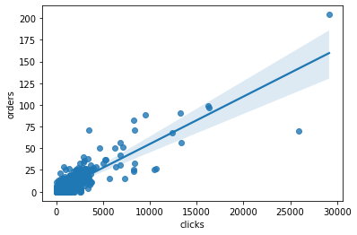

```python
sns.regplot(x=df2["clicks"],y=df2["orders"])
```

# observation 5

correlation cofficient of the clicks and orders is 0.877 which is showing strong correlation hence clicks has impact on the order. if we have more number of clicks we can have more orders .

```python
##product proformance carts and orders correlation
carts=df2["carts"]
orders=df2["orders"]

correlation = carts.corr(orders)
correlation
```

```
0.8019044616776909
```

# observation 6

correlation cofficient of the carts and orders is 0.80190 which is showing strong correlation hence carts has impact on the order. if we have more number of cart value we can have more orders .

```python
##product proformance carts and orders correlation
carts=df2["carts"]
click=df2["clicks"]

correlation = carts.corr(click)
correlation
```

```
0.730533231894646
```

# observation 7

correlation cofficient of the carts and clicks is 0.7305 which is showing positive correlation .

# for Merging renaming the pid to PID

```python
df2.rename(columns={'pId':"PID"},inplace=True)
df2
```

|  | PID | pName | clicks | carts | orders |
| --- | --- | --- | --- | --- | --- |
| 0 | CL0034516 | Chevron stripe colorblock maxi dress | 29144 | 2181 | 204 |
| 1 | CL0037085 | Chevron stripe colorblock maxi dress | 25892 | 237 | 70 |
| 2 | CL0036758 | Bird print pleated cotton knit dress | 16343 | 340 | 97 |
| 3 | CL0032310 | Cotton knit fit and flare dress | 16234 | 350 | 99 |
| 4 | CL0037110 | Pleat front chambray denim maxi dress | 13317 | 229 | 56 |
| ... | ... | ... | ... | ... | ... |
| 2496 | CL0036376 | Name N/A | 0 | 0 | 1 |
| 2497 | CL0035627 | Heart print cotton A-line dress | 0 | 0 | 1 |
| 2498 | GC0000202 | Name N/A | 0 | 0 | 5 |
| 2499 | GC0000204 | Name N/A | 0 | 0 | 7 |
| 2500 | GC0000205 | Name N/A | 0 | 0 | 11 |

2501 rows × 5 columns

# merging df1(Product description) and df2(Product proformance Table)

```python
df = pd.merge(df1, df2, on="PID")
```

```python
##deleting the p name from the table
del df['pName']
```

```python
df
```

[output not shown]

```python
df.describe()
```

|  | clicks | carts | orders |
| --- | --- | --- | --- |
| count | 716.000000 | 716.000000 | 716.000000 |
| mean | 1251.307263 | 27.124302 | 7.414804 |
| std | 1756.000433 | 37.003042 | 10.478603 |
| min | 14.000000 | 0.000000 | 0.000000 |
| 25% | 433.500000 | 8.000000 | 2.000000 |
| 50% | 851.000000 | 17.000000 | 4.000000 |
| 75% | 1527.000000 | 32.000000 | 9.000000 |
| max | 25892.000000 | 367.000000 | 97.000000 |

# Ploting bar grapth to observe which fabric user has ordered more .

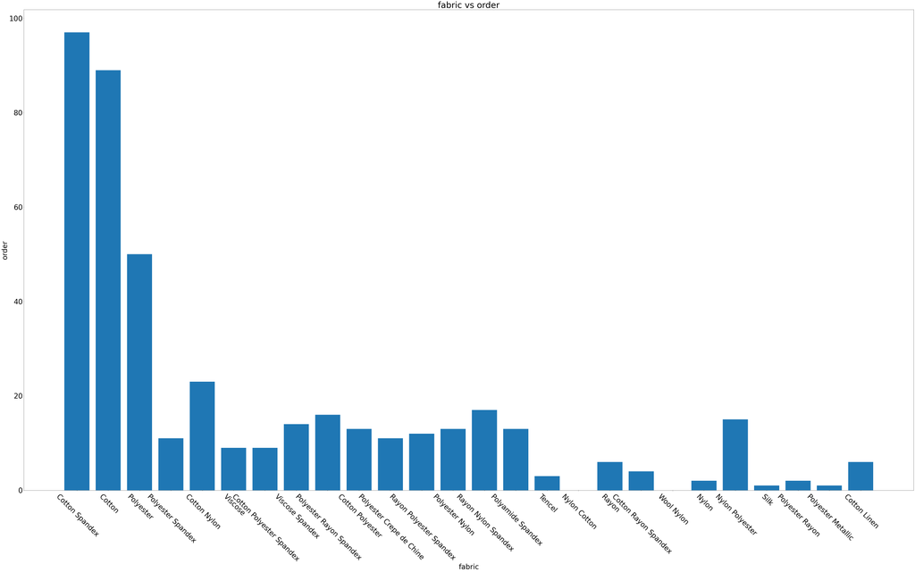

```python
fig=plt.figure(figsize=(90,50))
plt.rcParams.update({'font.size': 40},)
plt.bar(df['Fabric'],df['orders'])
plt.xlabel("fabric")
plt.ylabel("order")
plt.title("fabric vs order")
plt.xticks(rotation=-45)
plt.show()
```

# Observation 8

user has ordered Cotton Spandex more, if we add more Cotton Spandex product may order frequency increase

# Ploting bar grapth to observe which fabric user has clicked more .

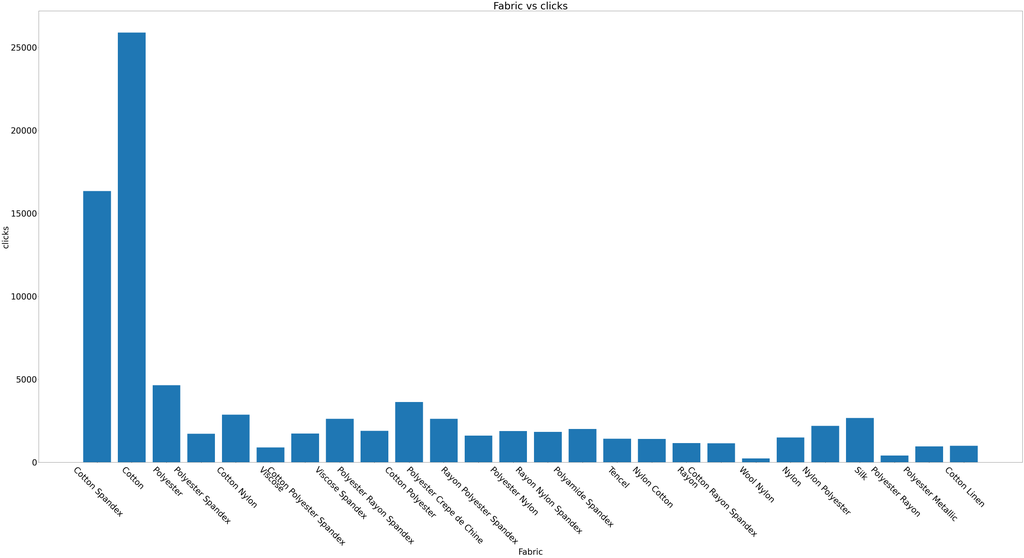

```python
fig=plt.figure(figsize=(85,40))
plt.rcParams.update({'font.size':40})
plt.bar(df['Fabric'],df['clicks'])
plt.xlabel('Fabric')
plt.ylabel('clicks')
plt.xticks(rotation=-45)
plt.title('Fabric vs clicks')
```

# Observation 9

user has click more on cotton fabric hence preference of user is cotton more

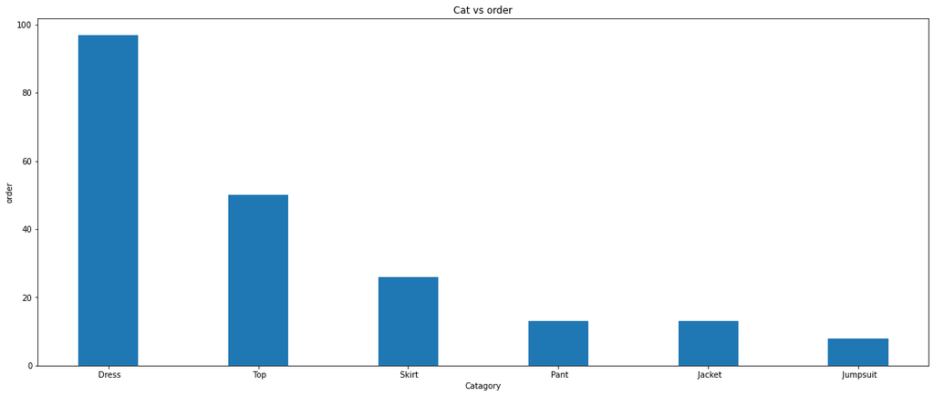

```python
### bar grapgh of catagory and order to see which category has been order more
fig=plt.figure(figsize=(20,8))
plt.rcParams.update({"font.size":10})
plt.bar(df['Category'],df['orders'],width=0.4)
plt.xlabel('Catagory')
plt.ylabel('order')
plt.title('Cat vs order')
```

# Observation 10

User has order Dress category more hence if we provide Dress catagory more in user serch converation can increase .

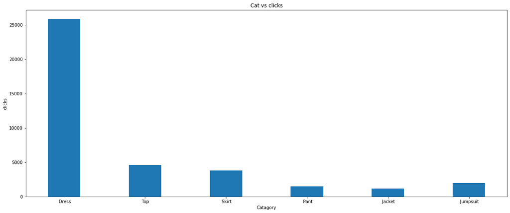

```python
##Bar graph to check which catagory user has click more .
fig=plt.figure(figsize=(20,8))
plt.rcParams.update({"font.size":10})
plt.bar(df['Category'],df['clicks'],width=0.4)
plt.xlabel('Catagory')
plt.ylabel('clicks')
plt.title('Cat vs clicks')
```

# observation 11

User has click on dress catagory more hecen Dress catagory has more demand .

```python
##Count operation based on the color
df["Color"].value_counts()
```

```
 Black                         39
 Deep navy                     23
 Deep indigo                   21
 Black/white                   18
 Black multi                   17
                               ..
 Red/white                      1
 Off-white/yellow               1
 Deep navy/royal blue/white     1
 Royablue/black                 1
 Black/spring green             1
Name: Color, Length: 327, dtype: int64
```

```python
##count operation on primary color
df["Primary Color"].value_counts()
```

```
 Black                 100
 White                  59
 Off-white              56
 Deep navy              44
 Deep indigo            29
                      ...
 Tiger lily              1
 Rose smoke              1
 Light jade green        1
 Powder blue             1
 Spring green multi      1
Name: Primary Color, Length: 122, dtype: int64
```

```python
#catagory=df["Category"]
#fabric=df["Fabric"]

catagory=df["Category"].value_counts()
catagory
```

```
 Dress       428
 Top         147
 Skirt        72
 Pant         49
 Jumpsuit     11
 Jacket        9
Name: Category, dtype: int64
```

# observation 12

Black color has more count hence user choise of color is Black more .

# Observation 13

Catagory Dress has more count hence user prefer dress more.

# Observation 14

# Filtering the No Name data from main data product proformance sheet 2

```python
No_name_data=df2.loc[df2["Product Name"]=='Name N/A',: ]
No_name_data
```

[output not shown]

1230 rows × 5 columns

# Filtering the product which has name

```python
data_with_name=df2.loc[df2["Product Name"]!='Name N/A',: ]
data_with_name
```

[output not shown]

1271 rows × 5 columns

```python
No_name_data_mean=np.mean(No_name_data)
No_name_data_mean
```

```
clicks    45.372358
carts      0.016260
orders     0.231707
dtype: float64
```

```python
data_with_name_mean=np.mean(data_with_name)
data_with_name_mean
```

```
clicks    1028.031471
carts       23.406766
orders       6.007081
dtype: float64
```

# Observation 15

From the Above observation it is clear that the product has "no name" customer has click very less compare to product which has name . conversation of "No name " product in cart and order is very low compare to the Product which has name

If supplier replace the "No name" product with product name conversation rate can increase

# Conclussion

1. click has more impact on the orders hence if clicks increase conversation may increase
2. carts also has strong correlation with orders .
3. Dress category has more count if hence conversation can increase with dress catagory
4. Jacket has very low clicks and user preference was more cotton and cotton spandax it show that this data set is of summer or user most preference are cotton dress.
5. if No Name product replaced by the Product name conversation rate may increase.
6. in Color user preference is Black most hence focusing on the color paramertes also can increase the conversation ration.